# Road Accident Analysis In UK

```python
#Merge all the data into Single dataframe.
Accident_data = pd.concat([Accident_2016_monthly,Accident_2017_monthly,Accident_2018_monthly,Accident_2019_monthly])
Accident_data
```

| Date | Location_Easting_OSGR | Location_Northing_OSGR | Longitude | Latitude | Police_Force | Accident_Severity | Number_of_Vehicles | Number_of_Casualties | Day_of_Week | Local_Authority_(District) | 1st_Road_Class | 1st_Road_Number | Road_Type | Speed_limit | Junction_Detail | Junction_Control | 2nd_Road_Class | 2nd_Road_Number | Pedestrian_Crossing-Human_Control | Pedestrian_Crossing-Physical_Facilities | Light_Conditions | Weather_Conditions | Road_Surface_Conditions | Special_Conditions_at_Site | Carriageway_Hazards | Urban_or_Rural_Area | Did_Police_Officer_Attend_Scene_of_Accident |
| --- | --- | --- | --- | --- | --- | --- | --- | --- | --- | --- | --- | --- | --- | --- | --- | --- | --- | --- | --- | --- | --- | --- | --- | --- | --- | --- | --- |
| 2016-01-31 | 5.323857e+09 | 3.418419e+09 | -15585.439739 | 623330.465948 | 358013 | 33552 | 21651 | 15610 | 51651 | 4112554 | 49408 | 11281613 | 61545 | 450840.0 | 26418 | 20269 | 31244 | 4241348 | 107 | 10049 | 28738 | 21229 | 18331 | 1076 | 706 | 16025 | 14761 |
| 2016-02-29 | 4.627329e+09 | 3.013642e+09 | -13648.999206 | 542859.569037 | 304464 | 29214 | 18955 | 13820 | 43707 | 3509454 | 42768 | 9726710 | 53637 | 394350.0 | 22931 | 17390 | 26901 | 3438183 | 92 | 8375 | 22456 | 16123 | 14027 | 1019 | 526 | 14025 | 12800 |
| 2016-03-31 | 4.768961e+09 | 3.099846e+09 | -14454.525759 | 561793.594955 | 323143 | 30107 | 19793 | 14331 | 41800 | 3703156 | 44381 | 9547620 | 55618 | 405200.0 | 24208 | 18373 | 28445 | 3275701 | 124 | 8624 | 20900 | 15794 | 12867 | 988 | 730 | 14437 | 13356 |
| 2016-04-30 | 4.977681e+09 | 3.221861e+09 | -14679.914342 | 583745.615689 | 328423 | 31413 | 20828 | 14578 | 46980 | 3772347 | 46013 | 10172176 | 57602 | 419080.0 | 25173 | 19164 | 29965 | 3578716 | 95 | 9171 | 19167 | 16323 | 13720 | 965 | 575 | 14960 | 13936 |
| 2016-05-31 | 5.149273e+09 | 3.303141e+09 | -14890.181859 | 601635.876459 | 343249 | 32216 | 21249 | 15241 | 46959 | 3929065 | 47555 | 10550578 | 59733 | 432490.0 | 25961 | 19775 | 30682 | 3490108 | 95 | 9649 | 18804 | 15852 | 13420 | 816 | 648 | 15448 | 14379 |
| 2016-06-30 | 5.007306e+09 | 3.246308e+09 | -14433.850474 | 585061.144167 | 331607 | 31468 | 20661 | 14961 | 43899 | 3788923 | 46134 | 10384830 | 58275 | 422920.0 | 25266 | 19200 | 29750 | 3429537 | 118 | 9094 | 18358 | 17456 | 14229 | 882 | 641 | 15110 | 13891 |
| 2016-07-31 | 5.319484e+09 | 3.399623e+09 | -15457.020873 | 622009.939779 | 355391 | 33266 | 22154 | 15859 | 47768 | 4090737 | 49025 | 11207609 | 61614 | 451110.0 | 26078 | 19578 | 30748 | 3854152 | 120 | 9384 | 19515 | 16628 | 13578 | 898 | 607 | 16137 | 14775 |
| 2016-08-31 | 5.276634e+09 | 3.415134e+09 | -15381.665135 | 617662.465092 | 357517 | 33082 | 22031 | 15798 | 48058 | 4107447 | 48396 | 10923640 | 60976 | 453620.0 | 25773 | 19755 | 30886 | 3696961 | 119 | 9113 | 20447 | 17170 | 14155 | 891 | 571 | 16202 | 14684 |
| 2016-09-30 | 5.238387e+09 | 3.348798e+09 | -15276.561772 | 612873.228856 | 352711 | 32849 | 21667 | 15358 | 50881 | 4055015 | 48538 | 10604953 | 60322 | 442760.0 | 25814 | 20212 | 31347 | 3675930 | 146 | 9402 | 21114 | 17188 | 14338 | 1169 | 698 | 15744 | 14881 |
| 2016-10-31 | 5.137531e+09 | 3.297615e+09 | -15054.593036 | 601637.932774 | 345068 | 32253 | 21185 | 15337 | 46896 | 3962401 | 47445 | 10676440 | 58900 | 438460.0 | 25083 | 19402 | 30246 | 3674117 | 105 | 9707 | 24346 | 17016 | 14463 | 1083 | 659 | 15593 | 14442 |
| 2016-11-30 | 5.549893e+09 | 3.499702e+09 | -15762.379961 | 646158.916611 | 359471 | 34745 | 22559 | 16061 | 47228 | 4130917 | 51214 | 10935651 | 63587 | 462890.0 | 27782 | 20523 | 32683 | 3913355 | 235 | 10489 | 29526 | 21666 | 17717 | 1079 | 593 | 16522 | 15666 |
| 2016-12-31 | 4.922279e+09 | 3.126566e+09 | -13639.882031 | 571061.735867 | 320501 | 30583 | 19767 | 14430 | 46490 | 3669843 | 45231 | 9679110 | 56398 | 408780.0 | 24588 | 18111 | 28836 | 3667932 | 173 | 9570 | 27618 | 19741 | 15628 | 793 | 616 | 14578 | 13747 |
| 2017-01-31 | 5.069886e+09 | 3.221732e+09 | -14428.822510 | 590623.481287 | 327814 | 31642 | 20436 | 14733 | 47618 | 3776096 | 47704 | 9787282 | 58086 | 420470.0 | 25524 | 18356 | 29872 | 3659483 | 196 | 9106 | 27960 | 21054 | 17286 | 962 | 559 | 14996 | 14115 |
| 2017-02-28 | 4.408915e+09 | 2.790775e+09 | -12535.236606 | 513511.253628 | 281527 | 27577 | 17966 | 12904 | 38542 | 3245995 | 41221 | 8318794 | 50628 | 368000.0 | 22655 | 16058 | 26047 | 3023967 | 128 | 8336 | 21294 | 16771 | 12775 | 973 | 518 | 13071 | 12247 |
| 2017-03-31 | 4.978844e+09 | 3.123286e+09 | -13953.619166 | 578205.765869 | 311078 | 30930 | 20225 | 14331 | 45094 | 3588464 | 46827 | 9291043 | 57143 | 404740.0 | 24716 | 17977 | 29425 | 3180259 | 10 | 8961 | 21530 | 17418 | 13046 | 836 | 470 | 14472 | 13953 |
| 2017-04-30 | 4.377594e+09 | 2.724315e+09 | -12159.168507 | 507627.124627 | 269385 | 27095 | 17733 | 12757 | 41203 | 3116346 | 40862 | 8278042 | 50383 | 356170.0 | 22116 | 15716 | 25928 | 2914664 | 2 | 8074 | 17569 | 14081 | 11035 | 626 | 360 | 12729 | 12196 |
| 2017-05-31 | 5.007669e+09 | 3.111451e+09 | -13864.634721 | 580351.829076 | 318705 | 30978 | 20427 | 14527 | 42949 | 3670880 | 46776 | 9539121 | 57515 | 414480.0 | 24703 | 17559 | 28721 | 3283168 | -12 | 8553 | 18924 | 16919 | 13238 | 744 | 542 | 14758 | 14005 |
| 2017-06-30 | 5.214656e+09 | 3.249326e+09 | -14289.675305 | 603440.706166 | 325442 | 32143 | 21388 | 15111 | 46697 | 3752867 | 48605 | 9924309 | 60008 | 427910.0 | 25996 | 18621 | 30703 | 3332474 | 8 | 9301 | 18983 | 17443 | 13211 | 701 | 472 | 15354 | 14732 |
| 2017-07-31 | 4.971369e+09 | 3.125643e+09 | -14402.646052 | 580482.906800 | 318657 | 30983 | 20400 | 14662 | 47031 | 3667402 | 46394 | 9564885 | 57148 | 415180.0 | 25277 | 17902 | 29332 | 3268717 | -14 | 9056 | 19316 | 17478 | 13489 | 781 | 463 | 14767 | 13920 |
| 2017-08-31 | 4.794904e+09 | 3.053928e+09 | -13736.040066 | 559233.411677 | 309176 | 29801 | 19847 | 14366 | 43536 | 3556008 | 44976 | 8742474 | 54958 | 401590.0 | 24108 | 16696 | 27504 | 3419072 | 18 | 8466 | 19215 | 16101 | 12570 | 708 | 488 | 14340 | 13421 |
| 2017-09-30 | 4.997208e+09 | 3.145389e+09 | -14188.424813 | 581700.158124 | 311529 | 31108 | 20412 | 14539 | 47442 | 3595736 | 46949 | 9422403 | 57567 | 410800.0 | 25071 | 17576 | 29220 | 3105936 | -16 | 9214 | 21327 | 17842 | 13701 | 778 | 406 | 14620 | 14153 |
| 2017-10-31 | 5.028123e+09 | 3.156784e+09 | -14002.393358 | 583556.600223 | 315911 | 31150 | 20631 | 14636 | 45211 | 3644902 | 46948 | 9670245 | 57333 | 413170.0 | 25388 | 18001 | 29601 | 3582874 | 17 | 9598 | 24520 | 18536 | 13767 | 758 | 572 | 14711 | 14144 |
| 2017-11-30 | 5.220729e+09 | 3.292383e+09 | -14504.698097 | 605831.099442 | 328687 | 32332 | 21185 | 14983 | 46808 | 3787719 | 48983 | 10056176 | 59355 | 428750.0 | 25873 | 18401 | 30350 | 3548377 | 18 | 10009 | 28326 | 20062 | 16272 | 901 | 662 | 15201 | 14734 |
| 2017-12-31 | 4.565543e+09 | 2.859690e+09 | -12765.036627 | 530091.382489 | 290215 | 28321 | 18276 | 13444 | 41477 | 3348572 | 42819 | 8154321 | 52251 | 381670.0 | 22246 | 14920 | 25480 | 2825703 | 1 | 8360 | 25757 | 19665 | 16519 | 632 | 560 | 13505 | 12774 |
| 2018-01-31 | 4.661721e+09 | 2.931818e+09 | -12859.911788 | 540274.264030 | 292442 | 28787 | 18739 | 13337 | 41605 | 3372714 | 43369 | 9013592 | 53072 | 384740.0 | 22603 | 15405 | 25988 | 3269642 | -51 | 8855 | 24860 | 19411 | 15258 | 734 | 430 | 13661 | 13344 |
| 2018-02-28 | 4.080403e+09 | 2.564132e+09 | -11317.325170 | 473258.457542 | 259344 | 25237 | 16613 | 11880 | 36509 | 2989253 | 38129 | 7389297 | 46629 | 338280.0 | 19211 | 13146 | 21915 | 2613448 | -55 | 7456 | 19397 | 16245 | 13072 | 833 | 456 | 12095 | 11593 |
| 2018-03-31 | 4.265461e+09 | 2.674877e+09 | -11907.586747 | 495212.024300 | 264137 | 26372 | 17456 | 12280 | 39788 | 3059308 | 40016 | 7533306 | 48822 | 346360.0 | 21319 | 14627 | 24864 | 2712089 | -79 | 8302 | 18336 | 16121 | 12409 | 733 | 370 | 12382 | 12255 |
| 2018-04-30 | 4.398150e+09 | 2.748753e+09 | -12348.331587 | 510990.509271 | 276798 | 27079 | 18219 | 12844 | 39472 | 3192307 | 41224 | 7906013 | 50235 | 362980.0 | 21483 | 14916 | 24851 | 2724335 | -11 | 8185 | 17251 | 14938 | 11600 | 822 | 498 | 12932 | 12612 |
| 2018-05-31 | 4.891493e+09 | 3.079557e+09 | -13763.884589 | 568693.883716 | 302599 | 30157 | 20216 | 14240 | 42460 | 3503379 | 45760 | 9518860 | 56513 | 399530.0 | 24587 | 17131 | 28502 | 3163402 | -36 | 9288 | 17862 | 15424 | 12306 | 826 | 493 | 14378 | 14029 |
| 2018-06-30 | 5.010222e+09 | 3.114391e+09 | -14047.253048 | 581778.417042 | 313846 | 30848 | 20747 | 14520 | 48441 | 3628524 | 46948 | 9248731 | 57626 | 411600.0 | 24544 | 16751 | 28391 | 3153794 | 2 | 9639 | 17696 | 15643 | 12251 | 840 | 448 | 14806 | 14282 |
| 2018-07-31 | 4.734028e+09 | 2.925053e+09 | -13273.638960 | 549591.057362 | 305680 | 29143 | 19537 | 13977 | 43448 | 3519757 | 44215 | 8828058 | 54588 | 393210.0 | 23394 | 15806 | 26704 | 2881005 | -53 | 8648 | 17594 | 15215 | 12132 | 823 | 476 | 14116 | 13506 |
| 2018-08-31 | 4.359412e+09 | 2.804192e+09 | -12921.021699 | 511489.079329 | 281044 | 27141 | 18079 | 12930 | 39927 | 3236150 | 40794 | 8014718 | 50173 | 366170.0 | 21420 | 14584 | 24994 | 2976872 | -63 | 8506 | 17428 | 14501 | 11540 | 771 | 491 | 13032 | 12525 |
| 2018-09-30 | 4.857154e+09 | 3.039332e+09 | -13537.247198 | 563692.774106 | 300967 | 29921 | 19853 | 14011 | 45118 | 3479479 | 45759 | 8844394 | 55815 | 394950.0 | 24171 | 16699 | 28202 | 3080306 | -21 | 9365 | 20423 | 17188 | 12813 | 550 | 469 | 14185 | 14074 |
| 2018-10-31 | 4.834046e+09 | 3.013834e+09 | -13415.317749 | 560620.232902 | 301025 | 29792 | 19732 | 14182 | 43375 | 3477477 | 44808 | 9141051 | 55101 | 398780.0 | 24055 | 16772 | 28408 | 3138717 | -85 | 9043 | 22334 | 17117 | 13245 | 808 | 478 | 14184 | 13861 |
| 2018-11-30 | 4.869759e+09 | 3.027213e+09 | -13446.958426 | 564181.690741 | 302476 | 30019 | 19737 | 13803 | 42776 | 3497710 | 45393 | 8754744 | 55802 | 397230.0 | 24088 | 16581 | 28146 | 3080162 | -59 | 9810 | 27530 | 19525 | 14813 | 917 | 548 | 14213 | 14094 |
| 2018-12-31 | 4.369102e+09 | 2.740360e+09 | -12217.672989 | 507371.151350 | 273885 | 26902 | 17481 | 12593 | 39696 | 3163764 | 40984 | 8420315 | 50370 | 356610.0 | 22284 | 15133 | 25560 | 2990911 | -8 | 9029 | 25052 | 16971 | 13954 | 628 | 581 | 12755 | 12503 |
| 2019-01-31 | 4.471289e+09 | 2.792236e+09 | -12326.324620 | 518015.924593 | 282679 | 27510 | 18026 | 12805 | 38502 | 3253738 | 41578 | 8333764 | 51438 | 362885.0 | 23257 | 15476 | 26321 | 3094075 | -16 | 8890 | 24246 | 17877 | 14981 | 654 | 468 | 13017 | 13753 |
| 2019-02-28 | 4.119645e+09 | 2.534095e+09 | -11411.359255 | 477277.948512 | 258605 | 25279 | 16739 | 11804 | 38045 | 2987432 | 38235 | 7840215 | 47126 | 335120.0 | 21214 | 14317 | 24088 | 2893389 | -21 | 8101 | 19207 | 14176 | 10990 | 695 | 337 | 12009 | 12589 |
| 2019-03-31 | 4.293173e+09 | 2.633382e+09 | -11744.971384 | 496433.571874 | 267031 | 26233 | 17548 | 12210 | 38061 | 3086198 | 39832 | 8252528 | 49531 | 345838.0 | 21698 | 14459 | 24723 | 2846895 | -34 | 8585 | 18705 | 15473 | 11112 | 600 | 355 | 12427 | 13252 |
| 2019-04-30 | 4.193808e+09 | 2.618343e+09 | -11920.659986 | 488113.894597 | 266331 | 25801 | 17322 | 12348 | 37113 | 3080587 | 38990 | 8117971 | 48635 | 343374.0 | 21699 | 14466 | 24528 | 3017019 | -121 | 7693 | 16408 | 14334 | 11072 | 587 | 425 | 12457 | 12832 |
| 2019-05-31 | 4.515168e+09 | 2.815141e+09 | -12594.557869 | 524007.097593 | 285726 | 27722 | 18614 | 12991 | 41913 | 3300531 | 42009 | 9152044 | 52356 | 364997.0 | 23372 | 15881 | 26555 | 3078736 | -11 | 8423 | 16894 | 14751 | 11252 | 729 | 433 | 13226 | 13790 |
| 2019-06-30 | 4.360707e+09 | 2.671996e+09 | -12164.699740 | 505711.573295 | 268608 | 26773 | 17831 | 12618 | 42322 | 3117121 | 40480 | 8402699 | 50661 | 354584.0 | 21950 | 14584 | 24952 | 2791840 | -37 | 7933 | 16456 | 14468 | 11551 | 648 | 376 | 12783 | 13379 |
| 2019-07-31 | 4.531147e+09 | 2.785291e+09 | -12525.586954 | 524737.836101 | 287063 | 27625 | 18621 | 13225 | 40131 | 3318123 | 42079 | 8327207 | 52410 | 371909.0 | 22609 | 14878 | 25748 | 2827821 | -103 | 8360 | 17436 | 15863 | 12217 | 729 | 408 | 13353 | 13857 |
| 2019-08-31 | 4.470211e+09 | 2.733526e+09 | -12250.608485 | 516936.155345 | 282836 | 27326 | 18307 | 13089 | 41509 | 3270197 | 41027 | 8540121 | 51529 | 368423.0 | 22635 | 14759 | 25539 | 3112156 | -72 | 8214 | 17962 | 15658 | 12034 | 774 | 437 | 13304 | 13735 |
| 2019-09-30 | 4.597411e+09 | 2.807765e+09 | -12656.422277 | 531976.739489 | 284666 | 28125 | 18688 | 13217 | 42637 | 3301085 | 42487 | 8873330 | 52936 | 376101.0 | 22716 | 15111 | 25973 | 2944340 | -6 | 8528 | 19422 | 16611 | 13221 | 940 | 454 | 13467 | 14178 |
| 2019-10-31 | 4.509620e+09 | 2.778632e+09 | -12723.232971 | 524032.564859 | 276623 | 27724 | 18256 | 12984 | 37851 | 3213862 | 41832 | 8677659 | 51822 | 364488.0 | 22878 | 15356 | 26335 | 3171516 | -116 | 8607 | 22555 | 17586 | 13633 | 868 | 593 | 13187 | 14083 |
| 2019-11-30 | 4.844090e+09 | 2.975253e+09 | -12988.567175 | 558526.977605 | 295208 | 29716 | 19422 | 13626 | 45851 | 3422951 | 44678 | 9140399 | 55464 | 389408.0 | 25191 | 16462 | 28407 | 3418829 | -35 | 9528 | 27061 | 19596 | 15676 | 896 | 440 | 13972 | 15108 |
| 2019-12-31 | 4.254728e+09 | 2.602144e+09 | -11512.067349 | 491111.541847 | 262449 | 26036 | 17007 | 12241 | 39273 | 3045602 | 39490 | 7947394 | 48850 | 345073.0 | 21079 | 14345 | 24556 | 2807731 | -100 | 8494 | 24231 | 17906 | 14111 | 688 | 483 | 12365 | 13149 |

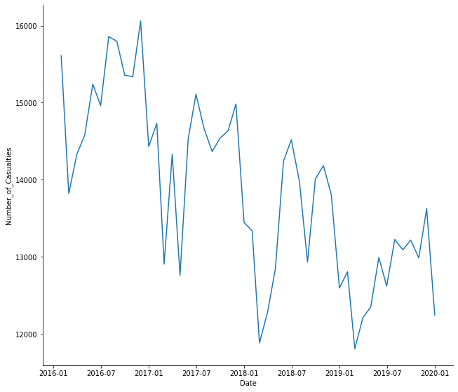

```python
sns.relplot(
    data=Accident_data, kind="line",
    x=Accident_data.index, y="Number_of_Casualties"
).fig.set_size_inches(10,8)
```

### Time Series Plot Analysis

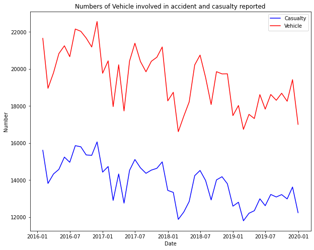

```python
plt.figure(figsize=(10, 8))
plt.plot(Accident_data.index, Accident_data['Number_of_Casualties'], 'b-', label = 'Casualty')
plt.plot(Accident_data.index, Accident_data['Number_of_Vehicles'], 'r-', label = 'Vehicle')
plt.xlabel('Date'); plt.ylabel('Number'); plt.title('Numbers of Vehicle involved in accident and casualty reported')
plt.legend();
```

```python
Accident_data['Year'] = pd.DatetimeIndex(Accident_data.index).year
Accident_data['Month'] = pd.DatetimeIndex(Accident_data.index).month
```

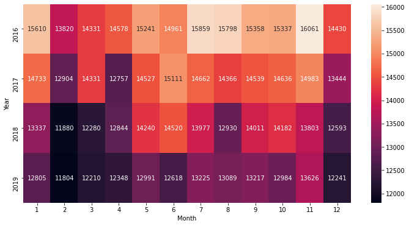

```python
heatmap = pd.pivot_table(data=Accident_data,values="Number_of_Casualties",
                         index='Year',columns='Month',aggfunc="mean",fill_value=0)
plt.figure(figsize=(12,6))
sns.heatmap(heatmap,annot=True,fmt="g")
```

[figure not shown]

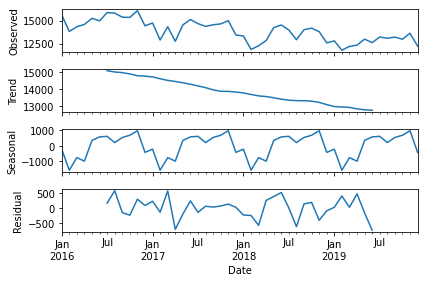

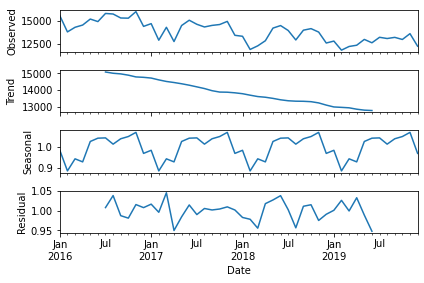

```python
#Decomposition Refers to separating a time series into trend, seasonal effects, and remaining variability

from statsmodels.tsa.seasonal import seasonal_decompose

# Time series decomposition plot
decompose_ts_add = seasonal_decompose(Accident_data.Number_of_Casualties,model="additive",freq=12)
decompose_ts_add.plot()
decompose_ts_mul = seasonal_decompose(Accident_data.Number_of_Casualties,model="multiplicative",freq=12)
decompose_ts_mul.plot()
```

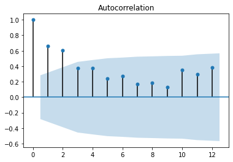

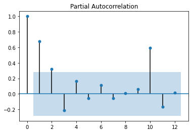

```python
# ACF plots and PACF plots on Original data sets
import statsmodels.graphics.tsaplots as tsa_plots
tsa_plots.plot_acf(Accident_data.Number_of_Casualties,lags=12)
tsa_plots.plot_pacf(Accident_data.Number_of_Casualties,lags=12)

# splitting the data into Train and Test data and considering the last 12 months data as
# Test data and left over data as train data

Train = Accident_data.head(36)
Test = Accident_data.tail(12)
# to change the index value in panda
```

```python
#Define MAPE(Mean Absolute Percentage Error) for error calculation
def MAPE(pred,org):
    Error = np.abs((pred-org)/org)*100
    return np.mean(Error)
Train["Number_of_Casualties"] = Train["Number_of_Casualties"].astype('double')
```

```python
from statsmodels.tsa.holtwinters import SimpleExpSmoothing # SES

ses_model = SimpleExpSmoothing(Train["Number_of_Casualties"]).fit()
pred_ses = ses_model.predict(start = Test.index[0],end = Test.index[-1])
MAPE(pred_ses,Test.Number_of_Casualties) # 3.76
```

```
3.757983794527936
```

```python
from statsmodels.tsa.holtwinters import Holt # Holts Exponential Smoothing
# Holt method
hw_model = Holt(Train["Number_of_Casualties"]).fit()
pred_hw = hw_model.predict(start = Test.index[0],end = Test.index[-1])
MAPE(pred_hw,Test.Number_of_Casualties) # 3.76
```

```
3.7580445488564354
```

```python
from statsmodels.tsa.holtwinters import ExponentialSmoothing #

# Holts winter exponential smoothing with additive seasonality and additive trend
hwe_model_add_add = ExponentialSmoothing(Train["Number_of_Casualties"],seasonal="add",
                                         trend="add",seasonal_periods=12).fit()
pred_hwe_add_add = hwe_model_add_add.predict(start = Test.index[0],end = Test.index[-1])
MAPE(pred_hwe_add_add,Test.Number_of_Casualties) # 3.22
```

```
3.2211417752627622
```

```python
# Holts winter exponential smoothing with multiplicative seasonality and additive trend
hwe_model_mul_add = ExponentialSmoothing(Train["Number_of_Casualties"],seasonal="mul",
                                         trend="add",seasonal_periods=12).fit()
pred_hwe_mul_add = hwe_model_mul_add.predict(start = Test.index[0],end = Test.index[-1])
MAPE(pred_hwe_mul_add,Test.Number_of_Casualties) #2.83
```

```
2.8309957371704098
```

### Exponential Smoothing

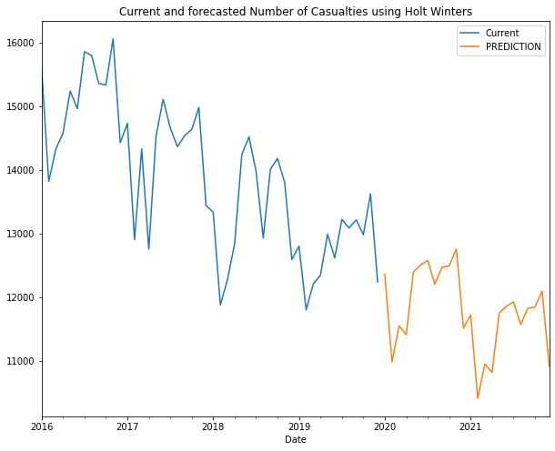

```python
fitted_model = ExponentialSmoothing(Accident_data['Number_of_Casualties'],trend='mul',
                                    seasonal= 'mul',seasonal_periods=12).fit()

test_predictions = fitted_model.forecast(24)

plt.figure(figsize=(10, 8))
plt.title('Current and forecasted Number of Casualties using Holt Winters')
Accident_data['Number_of_Casualties'].plot(legend=True,label='Current')
test_predictions.plot(legend=True,label='PREDICTION')
```

### Reason Behind Decline in Casulaty Cases

There is a negative trend in the casualty cases in coming years, what is the reason behind it, to analyze it i will see the paterns of the factor those were main reason behind the accident and will find the change in there behaviour across these years.For that i will first merge the accident,casualty and vehicle data based on their accident index and then merge it on year wise.

```python
#Merge 2016 Data by Accident Index
Accident_2016 = pd.read_csv("/content/dftRoadSafety_Accidents_2016.csv")
Data_2016 = pd.merge(Accident_2016,Casualties_2016,on = ['Accident_Index'])
Data2_2016 = pd.merge(Data_2016,Vehicles_2016,on = ['Accident_Index'])
Data2_2016.head(5)
```

|  | Accident_Index | Location_Easting_OSGR | Location_Northing_OSGR | Longitude | Latitude | Police_Force | Accident_Severity | Number_of_Vehicles | Number_of_Casualties | Date | Day_of_Week | Time | Local_Authority_(District) | Local_Authority_(Highway) | 1st_Road_Class | 1st_Road_Number | Road_Type | Speed_limit | Junction_Detail | Junction_Control | 2nd_Road_Class | 2nd_Road_Number | Pedestrian_Crossing-Human_Control | Pedestrian_Crossing-Physical_Facilities | Light_Conditions | Weather_Conditions | Road_Surface_Conditions | Special_Conditions_at_Site | Carriageway_Hazards | … |
| --- | --- | --- | --- | --- | --- | --- | --- | --- | --- | --- | --- | --- | --- | --- | --- | --- | --- | --- | --- | --- | --- | --- | --- | --- | --- | --- | --- | --- | --- | --- |
| 0 | 2016010000005 | 519310.0 | 188730.0 | -0.279323 | 51.584754 | 1 | 3 | 2 | 1 | 01/11/2016 | 3 | 02:30 | 28 | E09000005 | 3 | 4006 | 6 | 30.0 | 0 | -1 | -1 | 0 | 0 | 0 | 5 | 1 | 1 | 0 | 0 | … |
| 1 | 2016010000005 | 519310.0 | 188730.0 | -0.279323 | 51.584754 | 1 | 3 | 2 | 1 | 01/11/2016 | 3 | 02:30 | 28 | E09000005 | 3 | 4006 | 6 | 30.0 | 0 | -1 | -1 | 0 | 0 | 0 | 5 | 1 | 1 | 0 | 0 | … |
| 2 | 2016010000006 | 551920.0 | 174560.0 | 0.184928 | 51.449595 | 1 | 3 | 1 | 1 | 01/11/2016 | 3 | 00:37 | 18 | E09000004 | 3 | 207 | 6 | 30.0 | 9 | 4 | 6 | 0 | 0 | 0 | 4 | 1 | 1 | 0 | 0 | … |
| 3 | 2016010000008 | 505930.0 | 183850.0 | -0.473837 | 51.543563 | 1 | 3 | 1 | 1 | 01/11/2016 | 3 | 01:25 | 26 | E09000017 | 3 | 4020 | 1 | 30.0 | 1 | 4 | 3 | 4020 | 0 | 0 | 4 | 1 | 1 | 0 | 0 | … |
| 4 | 2016010000016 | 527770.0 | 168930.0 | -0.164442 | 51.404958 | 1 | 3 | 1 | 1 | 01/11/2016 | 3 | 09:15 | 22 | E09000024 | 3 | 217 | 6 | 30.0 | 3 | 2 | 3 | 217 | 0 | 0 | 1 | 1 | 1 | 0 | 0 | … |

```python
#Merge 2017 Data by Accident Index
Accident_2017 = pd.read_csv("/content/Acc2017.csv")
Data_2017 = pd.merge(Accident_2017,Vehicles_2017,on = ['Accident_Index'])
Data2_2017 = pd.merge(Data_2017,Vehicles_2017,on = ['Accident_Index'])
Data2_2017.describe()
```

|  | Location_Easting_OSGR | Location_Northing_OSGR | Longitude | Latitude | Police_Force | Accident_Severity | Number_of_Vehicles | Number_of_Casualties | Day_of_Week | Local_Authority_(District) | 1st_Road_Class | 1st_Road_Number | Road_Type | Speed_limit | Junction_Detail | Junction_Control | 2nd_Road_Class | 2nd_Road_Number | Pedestrian_Crossing-Human_Control | Pedestrian_Crossing-Physical_Facilities | Light_Conditions | Weather_Conditions | Road_Surface_Conditions | Special_Conditions_at_Site | Carriageway_Hazards | Urban_or_Rural_Area | Did_Police_Officer_Attend_Scene_of_Accident | Vehicle_Reference_x | Vehicle_Type_x | … |
| --- | --- | --- | --- | --- | --- | --- | --- | --- | --- | --- | --- | --- | --- | --- | --- | --- | --- | --- | --- | --- | --- | --- | --- | --- | --- | --- | --- | --- | --- | --- |
| count | 259654.000000 | 259654.000000 | 259626.000000 | 259626.000000 | 259708.000000 | 259708.000000 | 259708.000000 | 259708.000000 | 259708.000000 | 259708.000000 | 259708.000000 | 259708.000000 | 259708.000000 | 259708.000000 | 259708.000000 | 259708.000000 | 259708.000000 | 259708.000000 | 259708.000000 | 259708.000000 | 259708.000000 | 259708.000000 | 259708.000000 | 259708.000000 | 259708.000000 | 259708.000000 | 259708.000000 | 259708.000000 | 259708.000000 | … |
| mean | 449971.604277 | 321088.410042 | -1.276877 | 52.780792 | 9.993034 | 2.826644 | 2.461711 | 1.449717 | 4.111829 | 141.747747 | 4.028259 | 905.707645 | 5.058215 | 35.809563 | 2.525583 | 1.757212 | 2.895086 | 297.434095 | -0.002992 | 0.877335 | 2.044615 | 1.681565 | 1.248252 | 0.062081 | 0.030003 | 1.236462 | 1.259199 | 1.731729 | 9.874994 | … |
| std | 67967.949474 | 119271.615025 | 0.990884 | 1.077136 | 9.112825 | 0.406777 | 1.277188 | 0.944351 | 1.929284 | 114.028119 | 1.464653 | 1766.700277 | 1.728301 | 13.192376 | 2.636204 | 2.304178 | 3.151340 | 1111.260422 | 0.271210 | 1.989206 | 1.675390 | 1.930845 | 0.626008 | 0.627527 | 0.462905 | 0.425118 | 0.438459 | 1.003483 | 10.461041 | … |
| min | 296877.000000 | 151500.000000 | -3.594129 | 51.247045 | 1.000000 | 1.000000 | 1.000000 | 1.000000 | 1.000000 | 1.000000 | 1.000000 | 0.000000 | 1.000000 | 20.000000 | -1.000000 | -1.000000 | -1.000000 | -1.000000 | -1.000000 | -1.000000 | 1.000000 | 1.000000 | -1.000000 | -1.000000 | -1.000000 | 1.000000 | 1.000000 | 1.000000 | -1.000000 | … |
| 25% | 395186.000000 | 185890.000000 | -2.072870 | 51.556218 | 1.000000 | 3.000000 | 2.000000 | 1.000000 | 2.000000 | 25.000000 | 3.000000 | 0.000000 | 3.000000 | 30.000000 | 0.000000 | -1.000000 | -1.000000 | 0.000000 | 0.000000 | 0.000000 | 1.000000 | 1.000000 | 1.000000 | 0.000000 | 0.000000 | 1.000000 | 1.000000 | 1.000000 | 9.000000 | … |
| 50% | 436326.000000 | 333616.000000 | -1.454543 | 52.898157 | 7.000000 | 3.000000 | 2.000000 | 1.000000 | 4.000000 | 128.000000 | 3.000000 | 58.000000 | 6.000000 | 30.000000 | 3.000000 | 2.000000 | 4.000000 | 0.000000 | 0.000000 | 0.000000 | 1.000000 | 1.000000 | 1.000000 | 0.000000 | 0.000000 | 1.000000 | 1.000000 | 2.000000 | 9.000000 | … |
| 75% | 525370.000000 | 411914.000000 | -0.193004 | 53.601448 | 16.000000 | 3.000000 | 3.000000 | 2.000000 | 6.000000 | 233.000000 | 6.000000 | 595.000000 | 6.000000 | 40.000000 | 3.000000 | 4.000000 | 6.000000 | 0.000000 | 0.000000 | 0.000000 | 4.000000 | 1.000000 | 2.000000 | 0.000000 | 0.000000 | 1.000000 | 2.000000 | 2.000000 | 9.000000 | … |
| max | 558840.000000 | 654633.000000 | 0.341376 | 55.784991 | 48.000000 | 3.000000 | 14.000000 | 34.000000 | 7.000000 | 570.000000 | 6.000000 | 7910.000000 | 9.000000 | 70.000000 | 9.000000 | 4.000000 | 6.000000 | 8210.000000 | 2.000000 | 8.000000 | 7.000000 | 9.000000 | 5.000000 | 7.000000 | 7.000000 | 3.000000 | 3.000000 | 101.000000 | 98.000000 | … |

```python
#Merge 2018 Data by Accident Index
Accident_2018 = pd.read_csv("/content/dftRoadSafetyData_Accidents_2018.csv")
Data_2018 = pd.merge(Accident_2018,Casualties_2018,on = ['Accident_Index'])
Data2_2018 = pd.merge(Data_2018,Vehicles_2018,on = ['Accident_Index'])
Data2_2018.describe()
```

|  | Location_Easting_OSGR | Location_Northing_OSGR | Longitude | Latitude | Police_Force | Accident_Severity | Number_of_Vehicles | Number_of_Casualties | Day_of_Week | Local_Authority_(District) | 1st_Road_Class | 1st_Road_Number | Road_Type | Speed_limit | Junction_Detail | Junction_Control | 2nd_Road_Class | 2nd_Road_Number | Pedestrian_Crossing-Human_Control | Pedestrian_Crossing-Physical_Facilities | Light_Conditions | Weather_Conditions | Road_Surface_Conditions | Special_Conditions_at_Site | Carriageway_Hazards | Urban_or_Rural_Area | Did_Police_Officer_Attend_Scene_of_Accident | Vehicle_Reference_x | Casualty_Reference | … |
| --- | --- | --- | --- | --- | --- | --- | --- | --- | --- | --- | --- | --- | --- | --- | --- | --- | --- | --- | --- | --- | --- | --- | --- | --- | --- | --- | --- | --- | --- | --- |
| count | 270821.000000 | 2.708210e+05 | 270821.000000 | 270821.000000 | 270941.000000 | 270941.000000 | 270941.000000 | 270941.000000 | 270941.000000 | 270941.000000 | 270941.000000 | 270941.000000 | 270941.00000 | 270941.000000 | 270941.000000 | 270941.000000 | 270941.000000 | 270941.000000 | 270941.000000 | 270941.000000 | 270941.000000 | 270941.000000 | 270941.000000 | 270941.000000 | 270941.000000 | 270941.000000 | 270941.000000 | 270941.000000 | 270941.000000 | … |
| mean | 438054.364654 | 2.994161e+05 | -1.457019 | 52.582586 | 33.313105 | 2.758678 | 2.290916 | 1.957758 | 4.092205 | 384.644550 | 4.069517 | 887.421306 | 5.11621 | 40.801503 | 2.126950 | 1.468028 | 2.399936 | 312.900388 | 0.004606 | 0.680846 | 1.989939 | 1.560041 | 1.292005 | 0.089842 | 0.049457 | 1.433039 | 1.255240 | 1.642310 | 1.504305 | … |
| std | 96838.617305 | 1.571379e+05 | 1.421335 | 1.415271 | 23.464854 | 0.471688 | 1.158296 | 2.047860 | 1.950380 | 235.844542 | 1.537763 | 1730.796036 | 1.66557 | 15.386335 | 2.569552 | 2.375888 | 3.256890 | 1188.882982 | 0.176457 | 1.804704 | 1.714814 | 1.664953 | 0.579247 | 0.652536 | 0.486972 | 0.496568 | 0.452334 | 2.071566 | 2.984938 | … |
| min | 84654.000000 | 1.023500e+04 | -7.266148 | 49.912362 | 1.000000 | 1.000000 | 1.000000 | 1.000000 | 1.000000 | 1.000000 | 1.000000 | 0.000000 | 1.00000 | 20.000000 | -1.000000 | -1.000000 | -1.000000 | -1.000000 | -1.000000 | -1.000000 | 1.000000 | -1.000000 | -1.000000 | -1.000000 | -1.000000 | -1.000000 | -1.000000 | 1.000000 | 1.000000 | … |
| 25% | 373489.000000 | 1.757210e+05 | -2.399441 | 51.471067 | 13.000000 | 3.000000 | 2.000000 | 1.000000 | 2.000000 | 203.000000 | 3.000000 | 0.000000 | 3.00000 | 30.000000 | 0.000000 | -1.000000 | -1.000000 | 0.000000 | 0.000000 | 0.000000 | 1.000000 | 1.000000 | 1.000000 | 0.000000 | 0.000000 | 1.000000 | 1.000000 | 1.000000 | 1.000000 | … |
| 50% | 436827.000000 | 2.812210e+05 | -1.449127 | 52.422485 | 35.000000 | 3.000000 | 2.000000 | 1.000000 | 4.000000 | 384.000000 | 3.000000 | 47.000000 | 6.00000 | 30.000000 | 1.000000 | 2.000000 | 3.000000 | 0.000000 | 0.000000 | 0.000000 | 1.000000 | 1.000000 | 1.000000 | 0.000000 | 0.000000 | 1.000000 | 1.000000 | 2.000000 | 1.000000 | … |
| 75% | 515249.000000 | 3.987760e+05 | -0.325279 | 53.484014 | 46.000000 | 3.000000 | 2.000000 | 2.000000 | 6.000000 | 540.000000 | 6.000000 | 626.000000 | 6.00000 | 60.000000 | 3.000000 | 4.000000 | 6.000000 | 0.000000 | 0.000000 | 0.000000 | 4.000000 | 1.000000 | 2.000000 | 0.000000 | 0.000000 | 2.000000 | 1.000000 | 2.000000 | 2.000000 | … |
| max | 655275.000000 | 1.209512e+06 | 1.758123 | 60.763722 | 98.000000 | 3.000000 | 24.000000 | 59.000000 | 7.000000 | 941.000000 | 6.000000 | 9621.000000 | 9.00000 | 70.000000 | 9.000000 | 4.000000 | 6.000000 | 9620.000000 | 2.000000 | 8.000000 | 7.000000 | 9.000000 | 5.000000 | 7.000000 | 7.000000 | 3.000000 | 3.000000 | 999.000000 | 991.000000 | … |

```python
#Merge 2019 Data by Accident Index
Accident_2019 = pd.read_csv("/content/Road Safety Data - Accidents 2019.csv")
Data_2019 = pd.merge(Accident_2019,Casualties_2019,on = ['Accident_Index'])
Data2_2019 = pd.merge(Data_2019,Vehicles_2019,on = ['Accident_Index'])
Data2_2019.describe()
```

|  | Location_Easting_OSGR | Location_Northing_OSGR | Longitude | Latitude | Police_Force | Accident_Severity | Number_of_Vehicles | Number_of_Casualties | Day_of_Week | Local_Authority_(District) | 1st_Road_Class | 1st_Road_Number | Road_Type | Speed_limit | Junction_Detail | Junction_Control | 2nd_Road_Class | 2nd_Road_Number | Pedestrian_Crossing-Human_Control | Pedestrian_Crossing-Physical_Facilities | Light_Conditions | Weather_Conditions | Road_Surface_Conditions | Special_Conditions_at_Site | Carriageway_Hazards | Urban_or_Rural_Area | Did_Police_Officer_Attend_Scene_of_Accident | Vehicle_Reference_x | Casualty_Reference | … |
| --- | --- | --- | --- | --- | --- | --- | --- | --- | --- | --- | --- | --- | --- | --- | --- | --- | --- | --- | --- | --- | --- | --- | --- | --- | --- | --- | --- | --- | --- | --- |
| count | 151014.000000 | 151014.000000 | 151014.000000 | 151014.000000 | 151078.000000 | 151078.000000 | 151078.000000 | 151078.000000 | 151078.000000 | 151078.000000 | 151078.000000 | 151078.000000 | 151078.000000 | 151078.000000 | 151078.000000 | 151078.000000 | 151078.000000 | 151078.000000 | 151078.000000 | 151078.000000 | 151078.000000 | 151078.00000 | 151078.000000 | 151078.000000 | 151078.000000 | 151078.000000 | 151078.000000 | 151078.000000 | 151078.000000 | … |
| mean | 456493.732978 | 326454.060816 | -1.174803 | 52.828332 | 14.312819 | 2.762911 | 2.215359 | 1.843213 | 4.124194 | 188.194231 | 4.051272 | 974.313785 | 5.125498 | 37.070189 | 2.493394 | 1.648844 | 2.799190 | 356.273190 | -0.005911 | 0.937721 | 1.999609 | 1.59184 | 1.269212 | 0.068336 | 0.030143 | 1.295093 | 1.379552 | 1.581786 | 1.431320 | … |
| std | 68998.703749 | 108049.093871 | 1.010335 | 0.975781 | 11.584250 | 0.470421 | 0.945138 | 1.441966 | 1.950914 | 130.210884 | 1.447239 | 1833.666808 | 1.677766 | 14.059478 | 2.694365 | 2.313179 | 3.164328 | 1255.288358 | 0.273703 | 2.063751 | 1.669620 | 1.73009 | 0.582121 | 0.622358 | 0.427364 | 0.457014 | 0.624456 | 0.710685 | 0.958241 | … |
| min | 317571.000000 | 156781.000000 | -3.214535 | 51.295232 | 1.000000 | 1.000000 | 1.000000 | 1.000000 | 1.000000 | 1.000000 | 1.000000 | 0.000000 | 1.000000 | -1.000000 | -1.000000 | -1.000000 | -1.000000 | -1.000000 | -1.000000 | -1.000000 | 1.000000 | 1.00000 | -1.000000 | -1.000000 | -1.000000 | 1.000000 | 1.000000 | 1.000000 | 1.000000 | … |
| 25% | 403486.000000 | 246298.000000 | -1.949758 | 52.109028 | 4.000000 | 3.000000 | 2.000000 | 1.000000 | 2.000000 | 73.000000 | 3.000000 | 0.000000 | 3.000000 | 30.000000 | 0.000000 | -1.000000 | -1.000000 | 0.000000 | 0.000000 | 0.000000 | 1.000000 | 1.00000 | 1.000000 | 0.000000 | 0.000000 | 1.000000 | 1.000000 | 1.000000 | 1.000000 | … |
| 50% | 443705.000000 | 323145.000000 | -1.338514 | 52.794041 | 13.000000 | 3.000000 | 2.000000 | 1.000000 | 4.000000 | 203.000000 | 3.000000 | 59.000000 | 6.000000 | 30.000000 | 3.000000 | 2.000000 | 3.000000 | 0.000000 | 0.000000 | 0.000000 | 1.000000 | 1.00000 | 1.000000 | 0.000000 | 0.000000 | 1.000000 | 1.000000 | 1.000000 | 1.000000 | … |
| 75% | 524515.000000 | 404473.000000 | -0.198641 | 53.534925 | 22.000000 | 3.000000 | 2.000000 | 2.000000 | 6.000000 | 300.000000 | 6.000000 | 645.000000 | 6.000000 | 40.000000 | 3.000000 | 4.000000 | 6.000000 | 0.000000 | 0.000000 | 0.000000 | 4.000000 | 1.00000 | 2.000000 | 0.000000 | 0.000000 | 2.000000 | 2.000000 | 2.000000 | 2.000000 | … |
| max | 655108.000000 | 656571.000000 | 1.756019 | 55.802413 | 37.000000 | 3.000000 | 12.000000 | 25.000000 | 7.000000 | 416.000000 | 6.000000 | 9786.000000 | 9.000000 | 70.000000 | 9.000000 | 4.000000 | 6.000000 | 9899.000000 | 2.000000 | 8.000000 | 7.000000 | 9.00000 | 5.000000 | 7.000000 | 7.000000 | 3.000000 | 3.000000 | 20.000000 | 25.000000 | … |

```python
Final_Data = pd.concat([Data2_2016,Data2_2017,Data2_2018,Data2_2019])
Final_Data.head()
```

|  | Accident_Index | Location_Easting_OSGR | Location_Northing_OSGR | Longitude | Latitude | Police_Force | Accident_Severity | Number_of_Vehicles | Number_of_Casualties | Date | Day_of_Week | Time | Local_Authority_(District) | Local_Authority_(Highway) | 1st_Road_Class | 1st_Road_Number | Road_Type | Speed_limit | Junction_Detail | Junction_Control | 2nd_Road_Class | 2nd_Road_Number | Pedestrian_Crossing-Human_Control | Pedestrian_Crossing-Physical_Facilities | Light_Conditions | Weather_Conditions | Road_Surface_Conditions | Special_Conditions_at_Site | Carriageway_Hazards | … |
| --- | --- | --- | --- | --- | --- | --- | --- | --- | --- | --- | --- | --- | --- | --- | --- | --- | --- | --- | --- | --- | --- | --- | --- | --- | --- | --- | --- | --- | --- | --- |
| 0 | 2016010000005 | 519310.0 | 188730.0 | -0.279323 | 51.584754 | 1 | 3 | 2 | 1 | 01/11/2016 | 3 | 02:30 | 28 | E09000005 | 3 | 4006 | 6 | 30.0 | 0 | -1 | -1 | 0 | 0 | 0 | 5 | 1 | 1 | 0 | 0 | … |
| 1 | 2016010000005 | 519310.0 | 188730.0 | -0.279323 | 51.584754 | 1 | 3 | 2 | 1 | 01/11/2016 | 3 | 02:30 | 28 | E09000005 | 3 | 4006 | 6 | 30.0 | 0 | -1 | -1 | 0 | 0 | 0 | 5 | 1 | 1 | 0 | 0 | … |
| 2 | 2016010000006 | 551920.0 | 174560.0 | 0.184928 | 51.449595 | 1 | 3 | 1 | 1 | 01/11/2016 | 3 | 00:37 | 18 | E09000004 | 3 | 207 | 6 | 30.0 | 9 | 4 | 6 | 0 | 0 | 0 | 4 | 1 | 1 | 0 | 0 | … |
| 3 | 2016010000008 | 505930.0 | 183850.0 | -0.473837 | 51.543563 | 1 | 3 | 1 | 1 | 01/11/2016 | 3 | 01:25 | 26 | E09000017 | 3 | 4020 | 1 | 30.0 | 1 | 4 | 3 | 4020 | 0 | 0 | 4 | 1 | 1 | 0 | 0 | … |
| 4 | 2016010000016 | 527770.0 | 168930.0 | -0.164442 | 51.404958 | 1 | 3 | 1 | 1 | 01/11/2016 | 3 | 09:15 | 22 | E09000024 | 3 | 217 | 6 | 30.0 | 3 | 2 | 3 | 217 | 0 | 0 | 1 | 1 | 1 | 0 | 0 | … |

5 rows × 111 columns

### Preprocessing the data

There are few columns like Accident_Index,Location_Easting_OSGR Location_Northing_OSGR, Longitude,Latitude,Skidding_and_Overturning_x, Hit_Object_in_Carriageway_x which were not useful for further calculation so i will drop them for better efficiency and performance.

```python
Final_Data.drop(['Accident_Index', 'Location_Easting_OSGR', 'Location_Northing_OSGR','Longitude', 'Latitude',
                  'Time', 'Local_Authority_(District)', 'Local_Authority_(Highway)','1st_Road_Class', '1st_Road_Number',
                  'Junction_Detail', 'Junction_Control', '2nd_Road_Class','2nd_Road_Number', 'Pedestrian_Crossing-Human_Control',
                  'Pedestrian_Crossing-Physical_Facilities','Special_Conditions_at_Site', 'Carriageway_Hazards',
                  'LSOA_of_Accident_Location','Vehicle_Reference_x','Casualty_Reference','Age_Band_of_Casualty',
                  'Pedestrian_Location','Casualty_Home_Area_Type','Pedestrian_Road_Maintenance_Worker',
                   'Vehicle_Reference_y','Driver_Home_Area_Type','Vehicle_IMD_Decile',
                  'Driver_IMD_Decile','Propulsion_Code','Age_Band_of_Driver','Towing_and_Articulation',
                  'Vehicle_Manoeuvre','Vehicle_Location-Restricted_Lane','Junction_Location','Hit_Object_in_Carriageway',
                  'Vehicle_Leaving_Carriageway','Hit_Object_off_Carriageway', '1st_Point_of_Impact','Engine_Capacity_(CC)',
                  'Casualty_Severity','Casualty_Type','Sex_of_Driver_y', 'Age_of_Driver_y', 'Age_Band_of_Driver_y',
                   'Towing_and_Articulation_x', 'Vehicle_Manoeuvre_x','Vehicle_Location-Restricted_Lane_x',
                   'Junction_Location_x','Skidding_and_Overturning_x', 'Hit_Object_in_Carriageway_x',
                   'Vehicle_Leaving_Carriageway_x', 'Hit_Object_off_Carriageway_x','1st_Point_of_Impact_x',
                   'Was_Vehicle_Left_Hand_Drive?_x','Journey_Purpose_of_Driver_x', 'Sex_of_Driver_x',
                   'Age_of_Driver_x','Age_Band_of_Driver_x', 'Engine_Capacity_(CC)_x', 'Propulsion_Code_x',
                  'Age_of_Vehicle_x', 'Driver_IMD_Decile_x', 'Driver_Home_Area_Type_x','Vehicle_IMD_Decile_x',
                   'Vehicle_Type_y', 'Towing_and_Articulation_y','Vehicle_Manoeuvre_y',
                    'Vehicle_Location-Restricted_Lane_y','Junction_Location_y', 'Skidding_and_Overturning_y',
                    'Hit_Object_in_Carriageway_y', 'Vehicle_Leaving_Carriageway_y','Hit_Object_off_Carriageway_y',
                    '1st_Point_of_Impact_y','Was_Vehicle_Left_Hand_Drive?_y', 'Journey_Purpose_of_Driver_y',
                    'Sex_of_Driver_y', 'Age_of_Driver_y', 'Age_Band_of_Driver_y','Engine_Capacity_(CC)_y',
                     'Propulsion_Code_y', 'Age_of_Vehicle_y','Driver_IMD_Decile_y', 'Driver_Home_Area_Type_y',
                     'Vehicle_IMD_Decile_y','Vehicle_Type_x'], axis = 1,inplace = True)
Final_Data.head()
```

|  | Police_Force | Accident_Severity | Number_of_Vehicles | Number_of_Casualties | Date | Day_of_Week | Road_Type | Speed_limit | Light_Conditions | Weather_Conditions | Road_Surface_Conditions | Urban_or_Rural_Area | Did_Police_Officer_Attend_Scene_of_Accident | Casualty_Class | Sex_of_Casualty | Age_of_Casualty | Pedestrian_Movement | Car_Passenger | Bus_or_Coach_Passenger | Casualty_IMD_Decile | Vehicle_Type | Skidding_and_Overturning | Was_Vehicle_Left_Hand_Drive? | Journey_Purpose_of_Driver | Sex_of_Driver | Age_of_Driver | Age_of_Vehicle |
| --- | --- | --- | --- | --- | --- | --- | --- | --- | --- | --- | --- | --- | --- | --- | --- | --- | --- | --- | --- | --- | --- | --- | --- | --- | --- | --- | --- |
| 0 | 1 | 3 | 2 | 1 | 01/11/2016 | 3 | 6 | 30.0 | 5 | 1 | 1 | 1 | 1 | 1.0 | 1.0 | 23.0 | 0.0 | 0.0 | 0.0 | 4.0 | 8.0 | 0.0 | 1.0 | 1.0 | 1.0 | 51.0 | -1.0 |
| 1 | 1 | 3 | 2 | 1 | 01/11/2016 | 3 | 6 | 30.0 | 5 | 1 | 1 | 1 | 1 | 1.0 | 1.0 | 23.0 | 0.0 | 0.0 | 0.0 | 4.0 | 2.0 | 0.0 | 1.0 | 6.0 | 1.0 | 23.0 | 4.0 |
| 2 | 1 | 3 | 1 | 1 | 01/11/2016 | 3 | 6 | 30.0 | 4 | 1 | 1 | 1 | 1 | 1.0 | 2.0 | 36.0 | 0.0 | 0.0 | 0.0 | 10.0 | 9.0 | 2.0 | 1.0 | 6.0 | 2.0 | 36.0 | 1.0 |
| 3 | 1 | 3 | 1 | 1 | 01/11/2016 | 3 | 1 | 30.0 | 4 | 1 | 1 | 1 | 1 | 1.0 | 1.0 | 24.0 | 0.0 | 0.0 | 0.0 | 8.0 | 9.0 | 5.0 | 1.0 | 6.0 | 1.0 | 24.0 | 5.0 |
| 4 | 1 | 3 | 1 | 1 | 01/11/2016 | 3 | 6 | 30.0 | 1 | 1 | 1 | 1 | 1 | 2.0 | 2.0 | 59.0 | 0.0 | 0.0 | 3.0 | 4.0 | 11.0 | 0.0 | 1.0 | 1.0 | 1.0 | 55.0 | 7.0 |

```python
Final_Data.dropna().head()
```

|  | Police_Force | Accident_Severity | Number_of_Vehicles | Number_of_Casualties | Date | Day_of_Week | Road_Type | Speed_limit | Light_Conditions | Weather_Conditions | Road_Surface_Conditions | Urban_or_Rural_Area | Did_Police_Officer_Attend_Scene_of_Accident | Casualty_Class | Sex_of_Casualty | Age_of_Casualty | Pedestrian_Movement | Car_Passenger | Bus_or_Coach_Passenger | Casualty_IMD_Decile | Vehicle_Type | Skidding_and_Overturning | Was_Vehicle_Left_Hand_Drive? | Journey_Purpose_of_Driver | Sex_of_Driver | Age_of_Driver | Age_of_Vehicle |
| --- | --- | --- | --- | --- | --- | --- | --- | --- | --- | --- | --- | --- | --- | --- | --- | --- | --- | --- | --- | --- | --- | --- | --- | --- | --- | --- | --- |
| 0 | 1 | 3 | 2 | 1 | 01/11/2016 | 3 | 6 | 30.0 | 5 | 1 | 1 | 1 | 1 | 1.0 | 1.0 | 23.0 | 0.0 | 0.0 | 0.0 | 4.0 | 8.0 | 0.0 | 1.0 | 1.0 | 1.0 | 51.0 | -1.0 |
| 1 | 1 | 3 | 2 | 1 | 01/11/2016 | 3 | 6 | 30.0 | 5 | 1 | 1 | 1 | 1 | 1.0 | 1.0 | 23.0 | 0.0 | 0.0 | 0.0 | 4.0 | 2.0 | 0.0 | 1.0 | 6.0 | 1.0 | 23.0 | 4.0 |
| 2 | 1 | 3 | 1 | 1 | 01/11/2016 | 3 | 6 | 30.0 | 4 | 1 | 1 | 1 | 1 | 1.0 | 2.0 | 36.0 | 0.0 | 0.0 | 0.0 | 10.0 | 9.0 | 2.0 | 1.0 | 6.0 | 2.0 | 36.0 | 1.0 |
| 3 | 1 | 3 | 1 | 1 | 01/11/2016 | 3 | 1 | 30.0 | 4 | 1 | 1 | 1 | 1 | 1.0 | 1.0 | 24.0 | 0.0 | 0.0 | 0.0 | 8.0 | 9.0 | 5.0 | 1.0 | 6.0 | 1.0 | 24.0 | 5.0 |
| 4 | 1 | 3 | 1 | 1 | 01/11/2016 | 3 | 6 | 30.0 | 1 | 1 | 1 | 1 | 1 | 2.0 | 2.0 | 59.0 | 0.0 | 0.0 | 3.0 | 4.0 | 11.0 | 0.0 | 1.0 | 1.0 | 1.0 | 55.0 | 7.0 |

```python
Final_Data2 = Final_Data.copy()
```

Most of the columns present in the dataset were categorical,and they were represent by numbers, For the EDA i have to transform it into their respective text, so that at the time of visualiztion it's easy for me to understand and intrepret meaning from them.For that i will create the list for each attribute according to their respected number and then map it to the column.

```python
Vehicle_dict = {1:'Pedal Cycle',2:'Motorcycle 50cc',3:'Motorcycle 125cc',4:'Motorcycle 500cc',5:'Motorcycle over 500cc',8:'Taxi',9:'Car',10:'Minibus',
                11:'Bus',16:'Ridden Horse',17:'Agricultural Vehicle',18:'Tram',19:'Van/Goods 3.5T',20:'Goods 3.5T-7.5T',21:'Goods > 7.5T',
                22:'Mobility Scooter',23:'Electric Motorcycle',90:'Other',97:'Other',98:'Other',-1:'Other'}
Class_dict = {1:'Driver',2:'Passenger',3:'Pedestrian'}
Sex_dict = {1:'Male',2:'Female',-1:'Unknown'}
Left_drive = {1:'No',2:'Yes',-1:'Unknown'}
Skiding_dict = {0:'None',1:'Skidded',2:'Skidded and OverTurned',3:'Jackknifed',4:'Jackknifed and Overturned',5:'Overturned',-1:'Unknown'}
Severity_dict = {1: "Fatal", 2 : "Serious", 3 : "Light"}
Day_dict = {1: 'Sunday', 2 : 'Monday', 3 : 'Tuesday', 4 : "Wednesday", 5 : 'Thursday', 6 : "Friday", 7 : 'Saturday'}
Weather_dict = {1:'Fine',2:'Raining',3:'Snowing',4:'High WInds',5:'Raining+High winds',6:'Snowing+High Winds',
                7:'Fog',8:'Other',9:'Other',-1:'Other'}
Road_dict = {1:'Dry',2:'Wet or Dump',3:'Snow',4:'Frost or Ice',5:'Flood',6:'Oil',7:'Mud',-1:'Other'}
Urban_dict = {1:'Urban',2:'Rural',3:'Unallocated'}
Light_dict = {1:'Daylight',4:'Street Light',5:'Darkness',6:'Darkness',7:'Darkness',-1:'Unknown'}
Driver_dict = {1:'Male',2:'Female',3:'Unknown',-1:"Unknown"}
Journey_dict = {1:'journey for work',2:'To-From Work',3:'Pupil To-From School',4:'Pupil To-From School',5:'Other',6:'Unknown',15:'Unknown',-1:'Unknown'}
Road_type = {1:'Roundabout',2:'One Way Street',3:'Dual Carriageway',6:'Single Carriageway',7:'Slip Road',9:'Unkown',12:'One Way Street/Slip Road',-1:'Unknown'}
Car_pass = {0:'Not Car Passenger',1:'Front Seat Passenger',2:'Rear Seat Passenger',-1:'Unknown'}
Bus_Pass = {0:'Not a bus or coach Passenger',1:'Boarding',2:'Alighting',3:"Standing Passenger",4:'seated Passenger',-1:'Unknown'}

Final_Data2["Accident_Severity"] = Final_Data2["Accident_Severity"].map(Severity_dict)
Final_Data2["Day_of_Week"] = Final_Data2["Day_of_Week"].map(Day_dict)
Final_Data2["Road_Surface_Conditions"] = Final_Data2["Road_Surface_Conditions"].map(Road_dict)
Final_Data2["Urban_or_Rural_Area"] = Final_Data2["Urban_or_Rural_Area"].map(Urban_dict)
Final_Data2["Casualty_Class"] = Final_Data2["Casualty_Class"].map(Class_dict)
Final_Data2["Sex_of_Casualty"] = Final_Data2["Sex_of_Casualty"].map(Sex_dict)
Final_Data2["Vehicle_Type"] = Final_Data2["Vehicle_Type"].map(Vehicle_dict)
Final_Data2["Was_Vehicle_Left_Hand_Drive?"] = Final_Data2["Was_Vehicle_Left_Hand_Drive?"].map(Left_drive)
Final_Data2["Skidding_and_Overturning"] = Final_Data2["Skidding_and_Overturning"].map(Skiding_dict)
Final_Data2["Weather_Conditions"] = Final_Data2["Weather_Conditions"].map(Weather_dict)
Final_Data2["Light_Conditions"] = Final_Data2["Light_Conditions"].map(Light_dict)
Final_Data2["Sex_of_Driver"] = Final_Data2["Sex_of_Driver"].map(Driver_dict)
Final_Data2["Journey_Purpose_of_Driver"] = Final_Data2["Journey_Purpose_of_Driver"].map(Journey_dict)
Final_Data2["Road_Type"] = Final_Data2["Road_Type"].map(Road_type)
Final_Data2["Car_Passenger"] = Final_Data2["Car_Passenger"].map(Car_pass)
Final_Data2["Bus_or_Coach_Passenger"] = Final_Data2["Bus_or_Coach_Passenger"].map(Bus_Pass)
```